# Car Prices

```r
library(mosaic)
library(car)
library(tidyverse)
library(pander)
```

### **Background**

Cars are one of people’s most prized possessions. According to this year’s “Car Ownership Statistics”, around 88% of Americans own a car. Although there are many various cars brands, one of the more popular brand are Cadillacs. As such, data has been collected regarding this brand. Specifically, it’s price, mileage, model, trim, type, cylinder, interior, sound, and more were recorded. From this data, we would like to focus specifically on the model Caddillac Deville’s to determine whether mileage and sound affect the price of the car.

### **Hypothesis**

To determine if mileage and sound affect the car’s price, we first constructed our hypothesis as followed below; in which our first hypothesis tests to see if the Cadillac Deville’s will cost more when there is less miles while the second tests to see the price of this specific model given the miles and the sound.

$$\left.\begin{array}{ll}
H_0: \beta_2 = 0 \\
H_a: \beta_2 \neq 0
\end{array}
\right\} \text{Average Cost with Sound}$$
$$\left.\begin{array}{ll}
H_0: \beta_3 = 0 \\
H_a: \beta_3 \neq 0
\end{array}
\right\} \ \text{Price Affected by Mileage and Sound}$$

$$\underbrace{Y_i}_\text{Price of Cadillac Devilles} =
\overbrace{\beta_0}^\text{y-int} + \overbrace{\beta_1}^\text{slope}
\underbrace{X_i}_\text{Mileage} + \overbrace{\beta_2}^\text{change in
y-int} + \underbrace{X_i}_\text{sound} +
\overbrace{\beta_3}^\text{change in slope} +
\underbrace{X_2i}_\text{mileage:sound} + \epsilon_i \quad \text{where} \
\epsilon_i \sim N(0, \sigma^2)$$

### **Analysis**

```r
deville <- filter(CarPrices, Model == "Deville")
deville.lm <- lm(Price ~ Mileage + Sound + Mileage:Sound, data = deville)
regression <- summary(deville.lm)
pander(regression, caption = "Regression Model Between Mileage and Leather for Price")
```

|  | Estimate | Std. Error | t value | Pr(>\|t\|) |
| --- | --- | --- | --- | --- |
| **(Intercept)** | 42564 | 1649 | 25.81 | 4.679e-20 |
| **Mileage** | -0.3029 | 0.08196 | -3.696 | 0.001028 |
| **Sound** | -4309 | 2690 | -1.602 | 0.1213 |
| **Mileage:Sound** | 0.1522 | 0.1218 | 1.25 | 0.2225 |

[output not shown]

$$\beta_3 = \text{approximate
mileage:sound value} = \text{0.1522}$$

With this information, we can see the two separate equations between having a sound system and one without a sound system as followed:

**Without Sound**
$$\underbrace{\hat{Y}_i}_\text{Price} =
\overbrace{\text{42564}}^\text{est. y-int} +
\overbrace{\text{-0.3029}}^\text{est. slope} \underbrace {X_i}_{mileage}$$

**With Sound**
$$\underbrace{\hat{Y}_i}_\text{Price} =
\overbrace{\text{42564}}^\text{est. y-int} +
\overbrace{\text{-0.3029}}^\text{est. slope} + \overbrace{\text{-4309
}}^\text{est. y-int} + \overbrace{\text{0.1522}}^\text{est.change in
slope} \underbrace{X_i}_{sound}$$

[figure not shown]

```r
b <- coef(deville.lm)

ggplot(deville, aes(y=Price, x=Mileage, color=factor(Sound))) +
  geom_point(pch=16, bg="lightgray") +
  stat_function(fun = function(x) b[1] + b[2]*x, color="red1") + stat_function(fun = function(x) (b[1]+b[3]) + (b[2]+b[4])*x,color="cyan3") + #am==1 line
  scale_color_manual(name="Sound", values=c("red1","cyan3")) +
  labs(title="Two-lines Model using mtcars data set", which = 2)
```

### **Appropriateness of the Test**

To determine whether performing the multiple regression test is appropriate, we must analyze it’s residuals vs fitted plot, it’s QQ-Plot of residuals, and it’s Residuals vs Order plot.

As depicted below, our residual vs fitted plot appears to show a linear relationship and constant variance. However, the QQ-Plot doesn’t display a normality of error terns, nor does the residuals vs order, as it shows an trend which implies that the observations aren’t independent.

Although the QQ-Plot and Residuals VS Order plot doesn’t appear to be normal, for our purposes we will continue to test using a multiple linear regression.

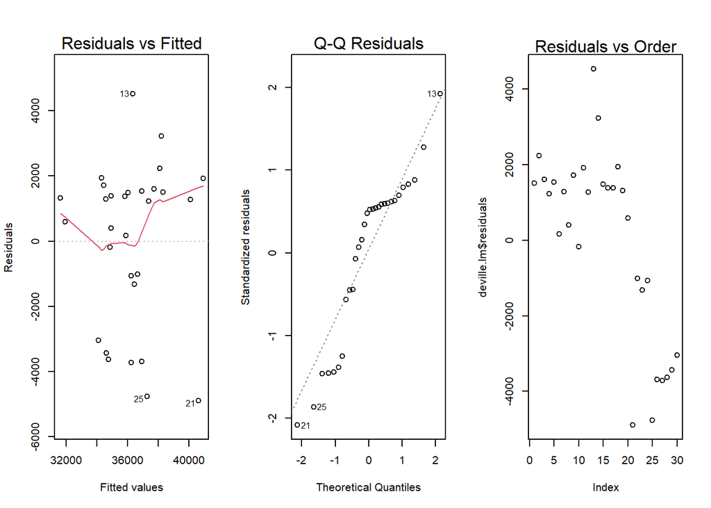

```r
par(mfrow = c(1,3))
plot(deville.lm, which=1:2)
plot(deville.lm$residuals)
mtext(side = 3, text="Residuals vs Order")
```